# An Exploratory Study on Drug Abuse Mortality by US County

PPHA 30538: Data Analytics and Visualization — Final Project Writeup

Authors

Group 32

Kanika Shokeen Section 3: Tues/Thurs 9:30 a.m. GitHub: shokeenkanika

Aleena Khan Section 1: Mon/Wed 9:00 a.m. GitHub: akxdata

GitHub: shokeenkanika/pubhealth-dataviz | Dashboard: [pubhealth-dataviz.streamlit.app](https://mcod-by-us-county.streamlit.app/) (Reminder: The app will likely ask to be woken up, just say yes!)

## Research Question

Drug overdose mortality varies substantially across US counties, shaped by geography, demographics, and state-level policies. This project explores and visualizes where deaths are highest, and how patterns differ by substance type, urbanization, sex, race, education, and state-level cannabis policies. We do not make causal claims about cannabis legalization and overdose mortality. Cannabis policy serves as a contextual lens for cross-county variation. If anything, the data may reflect selection bias: high-burden states may have adopted cannabis-friendly policies in response to their crisis, not the other way around.

## Data and Methods

We chose cannabis legalization as a proxy for a state’s broader harm-reduction infrastructure, as cannabis-friendly policies tend to accompany wider public health investments — rehabilitation access, healthcare worker training, and addiction support services. However, the literature cautions against causal interpretation: Shover et al. (2019, PNAS) found that the association between cannabis laws and opioid mortality reversed direction over time, consistent with our concern that high-burden states may have self-selected into reform policies.

## Static Figures

### Figure 1: T40.1 Heroin — Trends in the Highest-Burden Counties

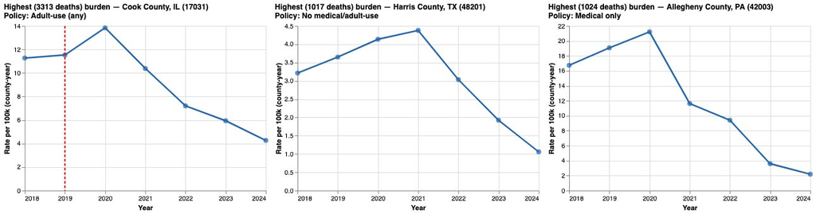

### Figure 2: Synthetic Opioids (Fentanyl) — Trends in the Highest-Burden Counties

This figure shows synthetic opioid death rates (2018–2024) for the three highest-burden counties across policy categories. Compared to Figure 1, this provides strong evidence of the fentanyl crisis in the US — most strikingly in Cook County, IL, where heroin-related deaths decreased as synthetic opioid-related deaths increased, a direct illustration of fentanyl substitution in the drug supply.

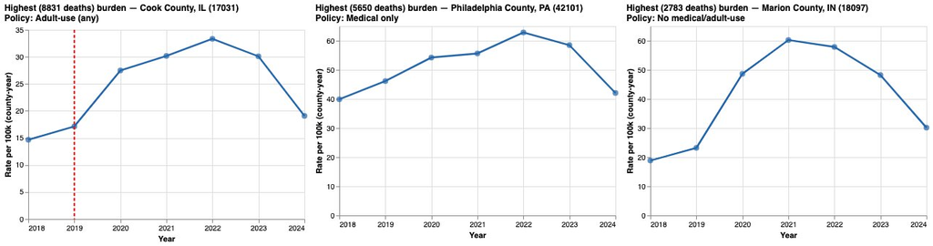

### Figure 3: Policy Category × Substance — Mean County Overdose Mortality Rate per 100k

These bar charts compare mean overdose mortality rates by substance and policy category. Synthetic opioids (T40.4) dominate across all three policy groups. Counterintuitively, counties with no cannabis policy show the lowest mean rates — consistent with our selection bias argument: high-burden states may have adopted cannabis-friendly policies in response to their crisis, not the other way around.

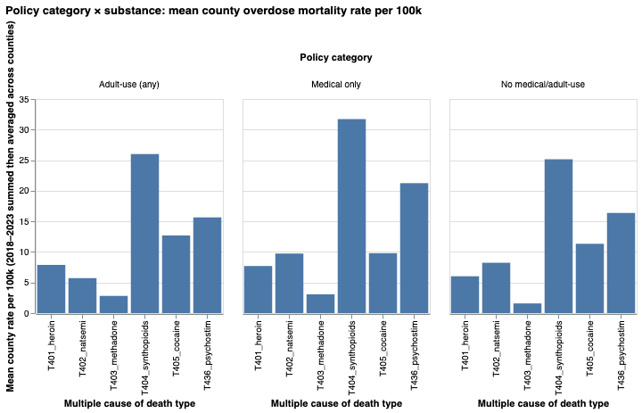

## Limitations and Future Directions

Two limitations are worth noting. First, the CDC Wonder portal suppresses counts below 10, meaning rural counties are likely underrepresented — reflecting reporting thresholds rather than an absence of deaths. Second, cannabis policy should not be interpreted causally, as discussed above. Future work could incorporate covariates like poverty rates, healthcare access, and naloxone availability, and explore why synthetic opioid mortality dominates so consistently across all policy environments.

## References

Shover, C. L., Davis, C. S., Gordon, S. C., & Humphreys, K. (2019). Association between medical cannabis laws and opioid overdose mortality has reversed over time. *Proceedings of the National Academy of Sciences, 116*(26), 12624–12626. https://doi.org/10.1073/pnas.1903434116